# Check-in 6

Author

Ryan Fernald

Remember, **follow the instructions below and use R Markdown to create a pdf document with your code and answers to the following questions on Gradescope.** You may find a template file by clicking “Code” in the top right corner of this page.

1. The following code downloads two sequences of 256 digits. One of them was generated by asking ChatGPT to generate to “sample 1000 random digits from 0 to 9 with replacement” (I only got 256). The other was generated using the R command `sample(0:9, 256, replace = T)`. Which is from R and which is from ChatGPT? Explain and justify your answer.

```r
A <- read.csv("https://math167r-s24.github.io/static/digits-a.csv")
B <- read.csv("https://math167r-s24.github.io/static/digits-b.csv")
```

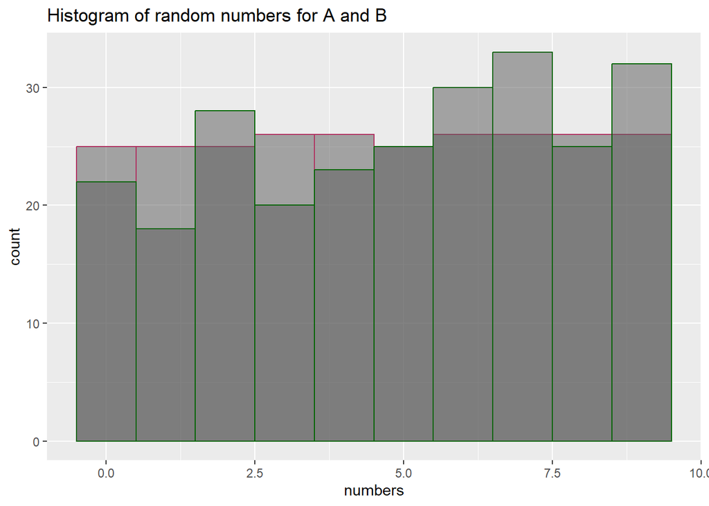

```r
library(ggplot2)
ggplot() +
  geom_histogram(aes(x = A$x),
                 alpha = .5, binwidth = 1, color = "maroon") +

  geom_histogram(aes(x = B$x),
                 alpha = .5, binwidth = 1, color = "darkgreen") +
  ggtitle("Histogram of random numbers for A and B") +
  xlab("numbers")
```

I would expect the data from B, to come from ChatGPT because it is more inconstant, The Data from A is more consistent, Given enough numbers we would expect a truly random number generator to be generating random numbers evenly, and with LLM’s we cannot trust things to be completely random because the next word is generated based on how likely it is to come after it.